# *Dialogues Concerning Natural Religion*, Part III

Philosophy 101 - Class 14

Brian Weatherson

weath@umich.edu

University of Michigan

October 12, 2023

## Inductive Arguments

**Enumerative Induction**: Lots of Fs are Gs, so all Fs are Gs. (This is what Russell thought was the only form of reasoning about the unobserved.)

**Analogy**: This unknown case is like this known case.

**Inference to the Best Explanation**: The best explanation of a puzzling phenomena is *p*, therefore *p*.

## Design Argument (Analogy)

1. Artifacts that serve a purpose are designed.
2. The universe serves a purpose.
3. So by analogy to these artifacts it is designed.

## Design Argument (IBE)

1. Things we see, especially living creatures, have complex parts that fit together well.
2. The best explanation of this is that they have a benevolent designer.
3. Hence that designer, i.e. God, exists.

## Plan for Today

I’m going to mostly still be talking about Part II.

But at the end we’ll get to Cleanthes’s replies in Part III.

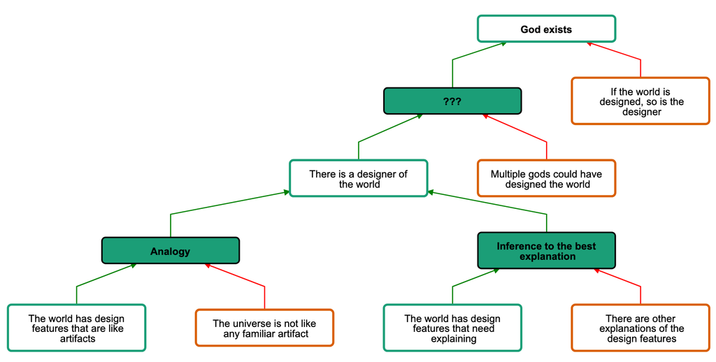

A brief summary of the argument.

## Historical Point

A lot of organised religions (definitely not all, but a lot of different ones) have been hostile to Darwinian theories of evolution.

At least part of that hostility was that Darwin’s theories undermined Design Argument (IBE).

It’s worth noting that (a) Hume is writing a century before Darwin, and (b) he sometimes writes as if Design Argument (Analogy) is the real form of the design argument.

## Historical Point

It isn’t just religious people who write this way.

In the 1990s and 2000s there was a very prominent strand of atheism (especially online) that made Darwin central to their position.

The line was roughly that Darwin, and only Darwin, had made it possible to be an intellectually respectable atheist.

This never struck me as a plausible view, i.e., the conjunction of views that atheism was correct and would be flawed without Darwin. And it’s really fascinating to read Hume with this in mind.

## Why Analogy

Cleanthes is going with the analogy at first.

Philo’s first point is that he is forced to reason by analogy, rather than using enumerative induction. (Note that IBE isn’t on the table yet.)

We don’t have other examples of worlds created by intelligent designers.

This is agreed on all sides.

## What Analogy

The analogy is supposed to be between artifacts (on the one hand) and animals or astronomical systems (on the other).

Philo’s main point is that what’s in the two hands is too dissimilar to justify an argument by analogy.

## Weak Analogy Objection

Philo has a barrage of points

1. Intuitive dissimilarity
2. Worries about inferring from effect to cause
3. Worries about psychological inference
4. Can’t infer from parts to wholes

We’ll go over these in turn

## Intuitive Dissimilarity

It would be a mistake to infer from the circulation of blood in humans to the circulation of sap in plants.

It would be a bit of a leap (though I think a justified one) to infer the circulation of blood in other primates.

But animals and plants are too dissimilar to justify this.

## Intuitive Dissimilarity

But animals and plants are more alike than animals and artifacts.

So if inference from animal to plant is bad, inference from artifact to animal is worse.

So this is a bad inference.

## Causes and Effects

The best cases of analogical reasoning are from causes to effects.

If one time we put our hand in a flame, and it hurts, we’ll infer that the next time we put our hand in a flame it will lead to the same effect, i.e. pain.

Same cause, same effect is a very plausible bit of reasoning; one so central that some Indian traditions treated it as a separate kind of argument.

## Causes and Effects

But it would be a serious mistake to infer that anyone else in pain but their hand in a flame.

This is a bad argument.

1. That person is in pain.
2. When I was in pain like that, it was because I’d put my hand in a flame.
3. So they must have put their hand in a flame.

## Causes and Effects

If we see similar designed cars, we’ll infer they behave in similar ways. (If you get a rental car of the same model you normally drive, you know how it works.)

But it’s a mistake to infer from the fact that cars are behaved in similar (not identical) ways that they have the same underlying causes.

Similar faults can be symptoms of very different underlying problems

## Causes and Effects

In general, it doesn’t take much observation to go from like cause to like effect, but it takes a lot to go from like effect to like cause.

That’s the hard direction to run analogical reasoning.

But that’s what the design inference does.

## Psychological Inference

Analogical reasoning is even harder in psychology.

- Minds are complicated and massively connected.
- Any part can have an impact on any other part.
- So there are many possible psychological causes of an action.

## Psychological Inference

To take a homely example, think of all the ways a person might choose to study at the University of Michigan.

It would be odd to infer on the basis of a few observations that people you don’t know chose UM for similar reasons to people you do know.

## Psychological Inference

But now imagine you’re trying to figure out why some people chose to study at Ohio State rather than Michigan.

Ohio State and Michigan are similar in some ways, more than animals and artifacts. (Not similar at football obviously, but they are big Midwestern state universities.)

But knowing why a few friends chose Michigan will be very little help in figuring out why students chose Ohio State.

## Summing Up

- Inferring from artifacts to animals is already a risky business.
- That the inference is from effect to cause, not cause to effect, makes it worse.
- That the cause in question is psychological makes it worse again.

Things look bad.

## iClicker Quiz

Which of them brings up the example of the “voice were heard in the clouds, much louder and more melodious than any which human art could ever reach”?

1. Cleanthes
2. Demea
3. Philo
4. None of them, it’s not in the book.

## Parts and Wholes

Philo worries that there might be some principle Cleanthes can use, e.g. parts are similar to the wholes they are of.

This would balance out the weaknesses of the argument.

Philo rejects that because of four examples.

## Parts and Wholes

- Generation of hair -> generation of humans
- Blowing of leaf -> behavior of tree
- Growing of embryo -> animalcule
- Economy of household -> economy of a nation (It’s wild that they think this is an obviously bad analogy.)

Cleanthes, in response, doesn’t try to defend such a principle.

## Cleanthes’ Responses

Cleanthes makes two responses:

- First, in some cases of successful analogical reasoning, the analogies have been similarly stretched.
- Second, we can imagine cases where we’d automatically infer a designer but the analogy would be just as stretched.

## Astronomy Analogy

The first move is made by looking at facts from the history of astronomy.

Cleanthes says that inferring from facts about earthly things to facts about the universe is no different from inferring from terrestrial mechanics to celestial mechanics.

## Astronomy Analogy

Cleanthes suggests that without this we can’t defend Copernican astronomy.

Philo thinks Cleanthes is wrong on the history here.

It’s true (remarkably) that the same basic principles underlie terrestrial and celestial motion.

But Philo thinks this is a conclusion.

## Astronomy Analogy

He argues that the early great astronomers (Galileo, Copernicus etc) reasoned from claims about other celestial bodies, especially the moon, to claims about earth’s behaviour.

They reasoned, that is, from like to like.

They then discovered that very different things have similar mechanics.

## Divine Voice Analogy

Cleanthes comes back with a stronger kind of case.

“Suppose that an articulate voice were heard in the clouds, much louder and more melodious than any which human art could ever reach … Must you not instantly assign to it some design or purpose?”

## Divine Voice Analogy

It is important to Cleanthes that this is an analogy not an enumerative induction.

The fact that the voice is so powerful and melodious means we can’t say “Ah, in cases like this in the past there was a purpose, so there is one here too,” because there are no such cases.

The Divine Voice case is really interesting I think, perhaps the best move Cleanthes makes in the book. And we’re going to spend a bit of time on it over the next couple of weeks.

## Books Analogy

This one is harder to follow.

- Imagine, says Cleanthes, that books could reproduce like animals.
- We would still attribute design to any book we found lying around.
- We would see “the strongest analogy to mind and intelligence” in them.

## Overgeneration

Cleanthes is making a very important kind of philosophical move here: an **overgeneration** argument.

Overgeneration arguments are when you take someone’s reasoning, and show that the same reasoning would work to show something actually wrong.

## Overgeneration

1. After hearing the Divine Voice, all of Philo’s premises would still be true.
2. After hearing the Divine Voice, Philo’s conclusion would be false.
3. So, Philo’s reasoning is faulty.
4. So, Philo’s reasoning doesn’t work *even in the world where we haven’t heard the Divine Voice*.

## Philo’s Move

After some inconsequential back-and-forth with Demea, Philo changes subject, apparently conceding.

I’m not sure Philo should have conceded.

Cleanthes may be running together the two design arguments here.

## The Divine Voice

The following is plausibly true:

- If we heard the Divine Voice, it would be very plausible that God exists.

But what Cleanthes needs is this:

- If we heard the Divine Voice, it would be very plausible *that the argument by analogy shows that* God exists.

And we could reject that.

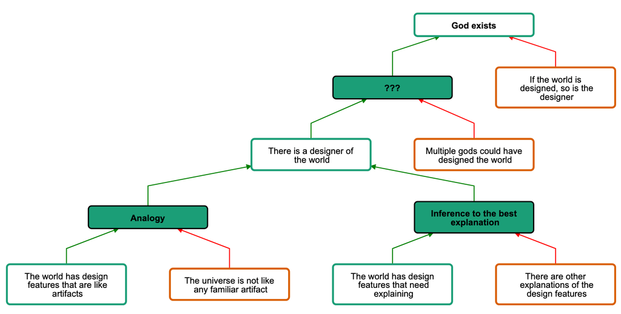

Philo needs to find some things he can retract if the Divine Voice appears.

## Design Arguments

In the world where the Divine Voice happens, one could coherently say:

1. The analogy argument is still bad; but
2. Now, the best explanation is God exists, so the IBE argument works.

## For Next Time

Read Parts 4 and 5 of Hume.

Hume will introduce the regress worry (short version, Who designed God?) and the worry about what we can learn about God from this argument.